# hw3_Question1

Looking at the pairs plot again:

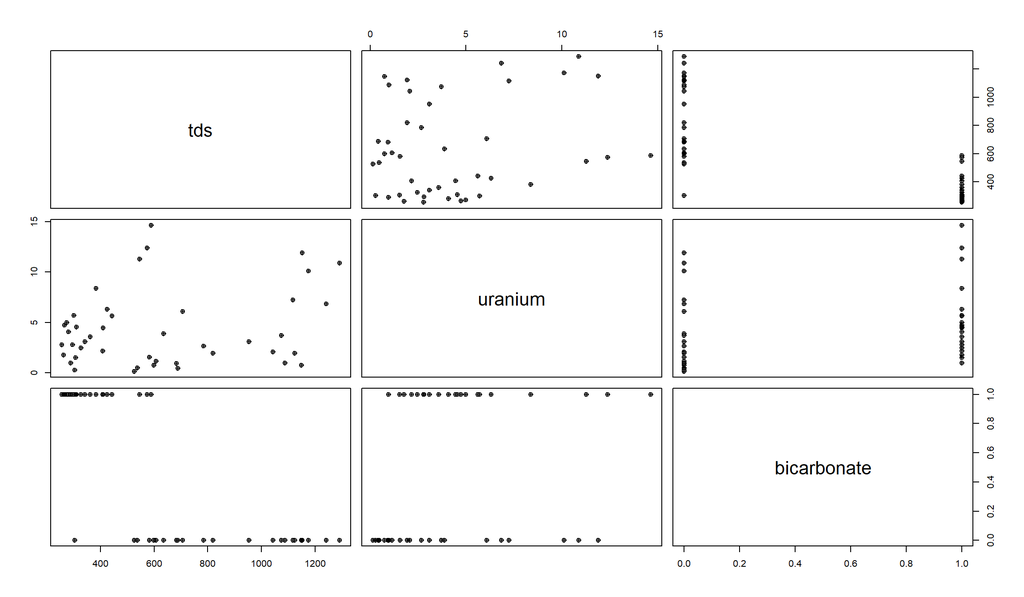

```r
pairs(app16, pch = 10)
```

I can observe that bicarbonate is a binary variable(having values 0 and 1). This makes me wonder whether the relationship is dependent on bicarbonate-(whether there is a different relationship when bicarbonate is 0, and a different relationship when the bicarbonate is 1), and tried visualizing the dataset using ggplot.

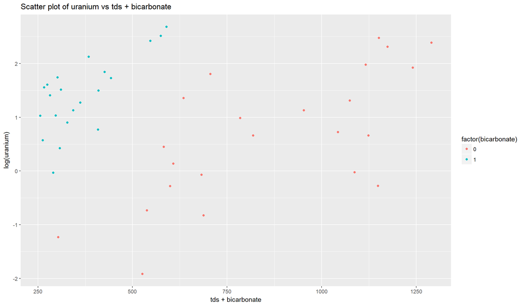

```r
ggplot(app16, aes(x = tds+bicarbonate, y = log(uranium))) +
  geom_point(aes(color=factor(bicarbonate)))+labs(title = "Scatter plot of uranium vs tds + bicarbonate")
```

The scatter plot confirms that there is a distinct linear relationship when bicarbonate is zero, and when it is 1. This means that we could group the dataset by bicarbonate, and fit a linear model for the two datasets. geom_smooth is used to smooth the dataset, to capture any important patterns in the grouped data.

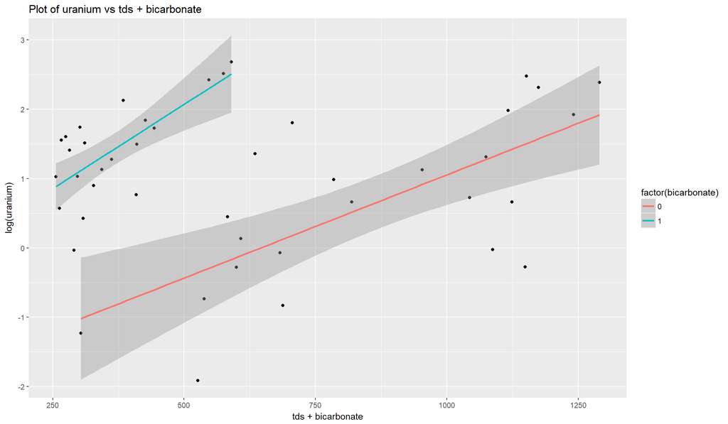

```r
ggplot(app16, aes(x = tds+bicarbonate, y = log(uranium))) +
  geom_point() +
  geom_smooth(method = 'lm', aes(color = factor(bicarbonate)) )+labs(title = "Plot of uranium vs tds + bicarbonate")
```

We can observe the slopes of the two lines are different. Since the relationship betweeen the log(uranium) and tds, for the two bicarbonate values is differing in intercept and also in slope, I tried to fit an interaction model. This model is referred to as an “interaction model” because of the use of the explanatory variable tds*bicarbonate , the interaction (product) of the original predictor tds and the binary variable bicarbonate .

Ref: Helsel and Hirsch, Chap 10 Multiple Regression.

```r
fit2 <- lm(log(uranium) ~tds + bicarbonate + tds * bicarbonate, data = app16)
summary(fit2)
```

```
Call:
lm(formula = log(uranium) ~ tds + bicarbonate + tds * bicarbonate,
    data = app16)

Residuals:
    Min      1Q  Median      3Q     Max
-1.7742 -0.3384  0.1012  0.4935  1.6282

Coefficients:
                  Estimate Std. Error t value Pr(>|t|)
(Intercept)     -1.9243143  0.5033330  -3.823 0.000451 ***
tds              0.0029783  0.0005548   5.368 3.64e-06 ***
bicarbonate      1.5684636  0.7856565   1.996 0.052731 .
tds:bicarbonate  0.0018846  0.0016901   1.115 0.271464
---
Signif. codes:  0 '***' 0.001 '**' 0.01 '*' 0.05 '.' 0.1 ' ' 1

Residual standard error: 0.7336 on 40 degrees of freedom
Multiple R-squared:  0.5559,    Adjusted R-squared:  0.5226
F-statistic: 16.69 on 3 and 40 DF,  p-value: 3.481e-07
```

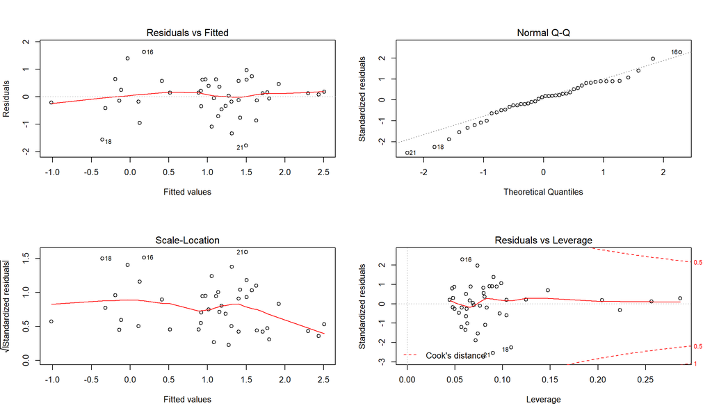

```r
par(mfrow=c(2,2))
plot(fit2)
```

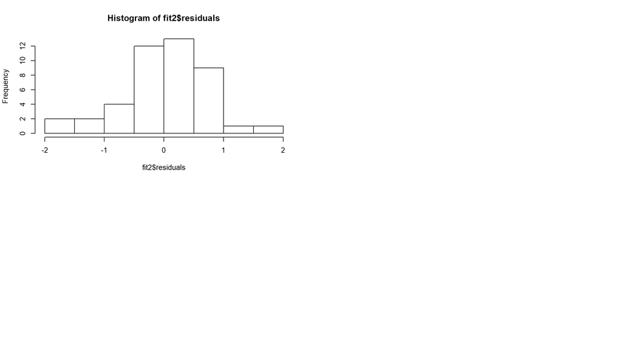

```r
hist(fit2$residuals)
```

However in the residuals vs fitted graph, there is still a clustering of the points, towards the right. But since this is a small dataset, we cannot generalize this. Maybe in a considerably large sample size, there wont be much clustering. In the residuals vs leverage graph, since all the points are within the Cook’s distance, the model is not sensitive to any specific outliers.

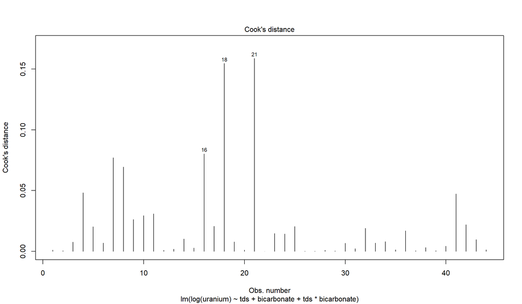

```r
library(mvinfluence)
cutoff <- 4/((nrow(app16)-length(fit2$coefficients)-2))
plot(fit2, which=4, cook.levels=cutoff)
```

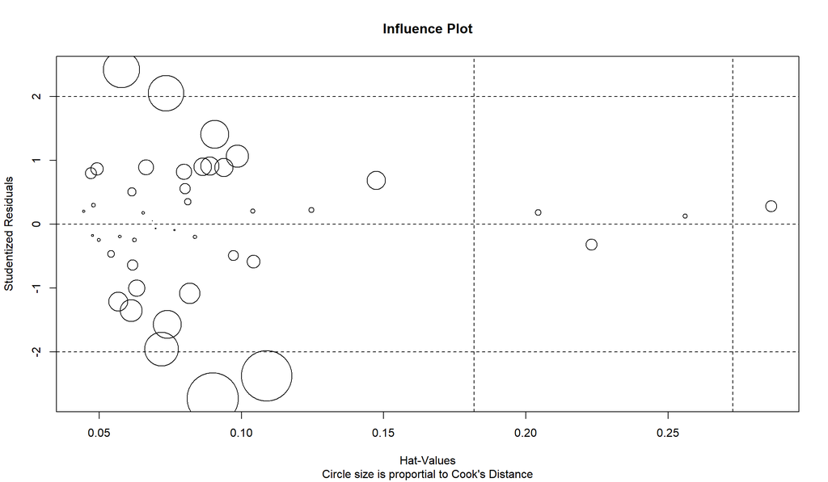

```r
# Influence Plot
influencePlot(fit2, id.method="identify", main="Influence Plot", sub="Circle size is proportial to Cook's Distance" )
```

Alternatively I tried splitting the dataset into two(grouping by bicarbonate variable), and tried to fit a linear model

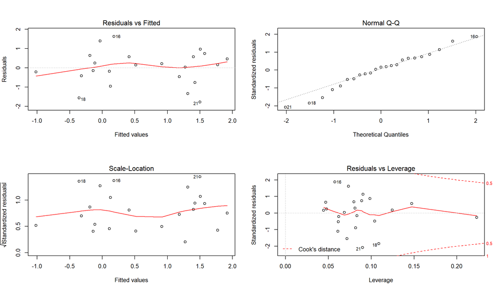

```r
bicab0 <- app16 %>%
          filter(bicarbonate==0)
bicab1 <- app16 %>%
          filter(bicarbonate==1)

fit3 <- lm(log(uranium) ~ tds + bicarbonate, data=bicab0)
par(mfrow=c(2,2))
plot(fit3)
```

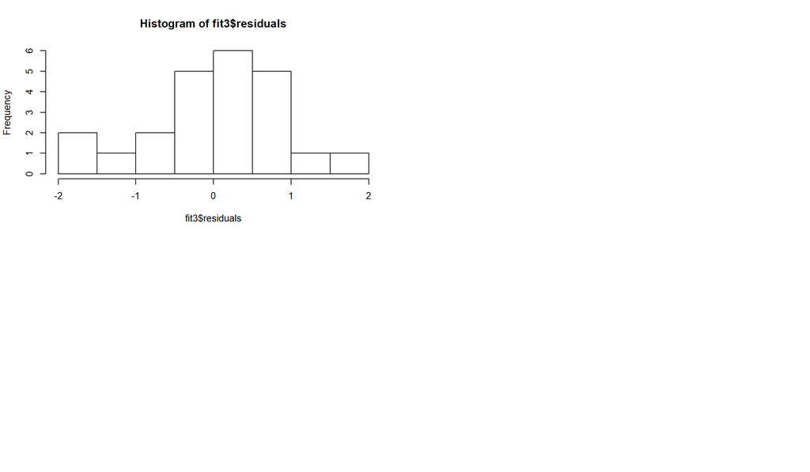

```r
hist(fit3$residuals)

fit4 <- lm(log(uranium) ~ tds + bicarbonate, data=bicab1)
par(mfrow=c(2,2))
```

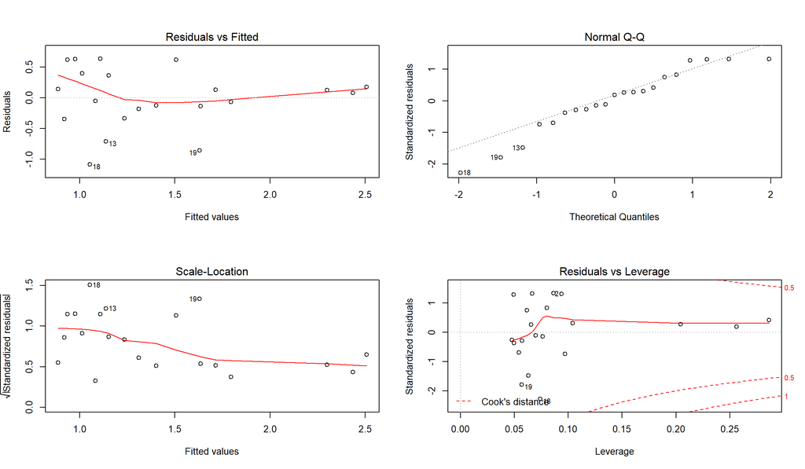

```r
plot(fit4)
```

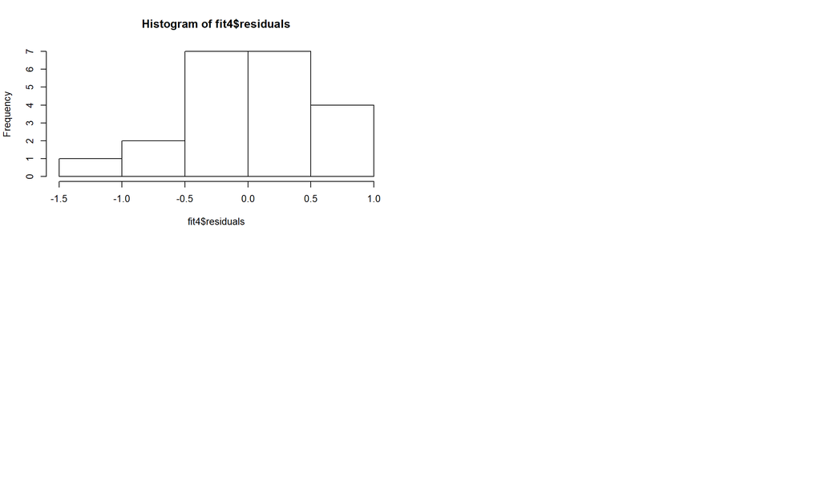

```r
hist(fit4$residuals)
```

It is observed that the two models fit well for the seperated data. But splitting the dataset into two, results in smaller datasets that can be used to fit a model. This could be a disadvantage, beacuse the smaller sample, may have a chance that it is not representative of the population itself.

Inorder to check points of high leverage and high influence that influence the regression coefficients, I plotted the InluencePlot for the two models.

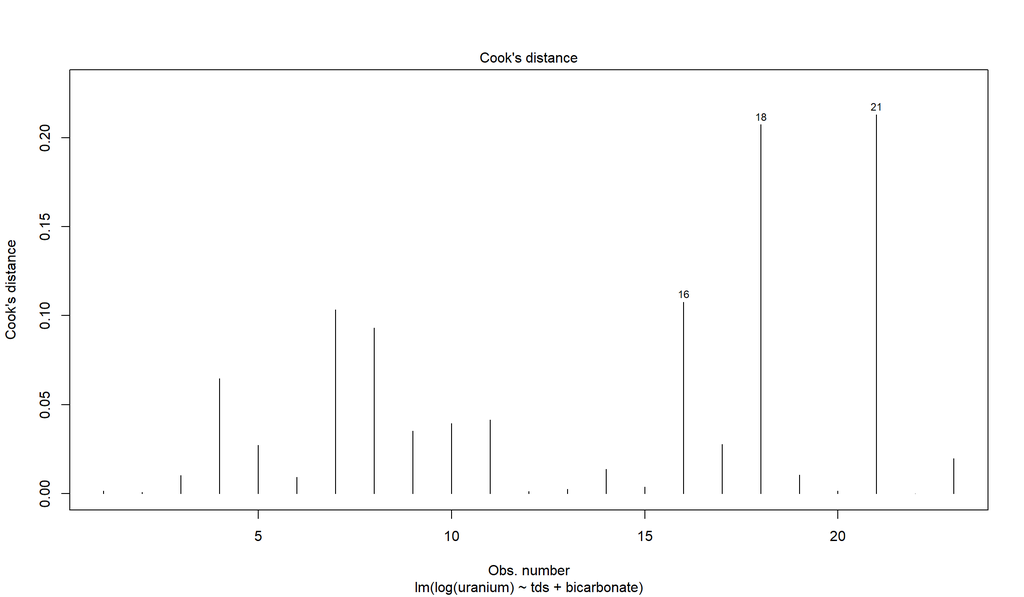

```r
cutoff <- 4/((nrow(app16)-length(fit3$coefficients)-2))
plot(fit3, which=4, cook.levels=cutoff)
```

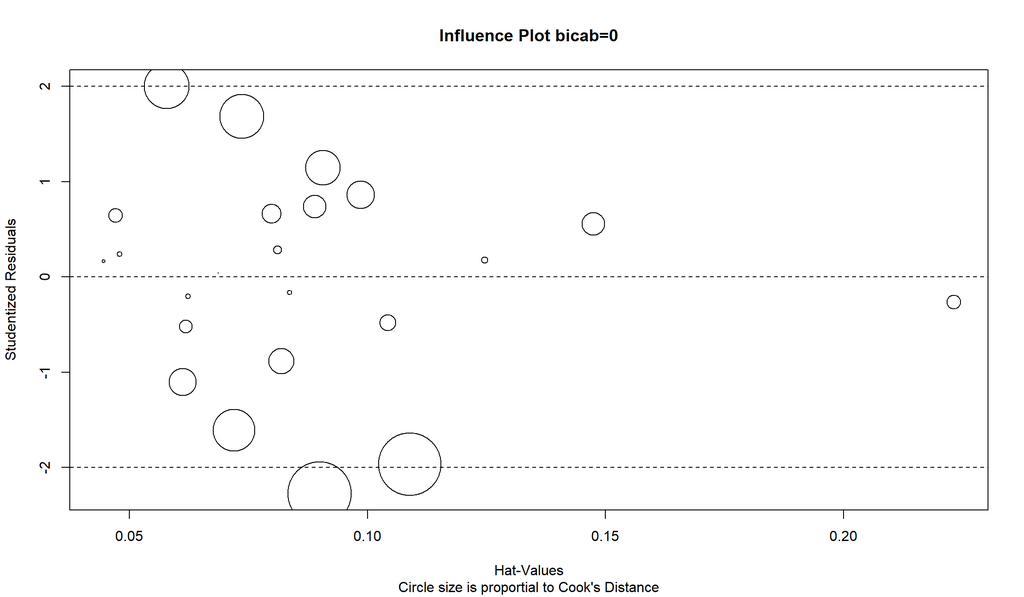

```r
# Influence Plot
influencePlot(fit3, id.method="identify", main="Influence Plot bicab=0", sub="Circle size is proportial to Cook's Distance" )
```

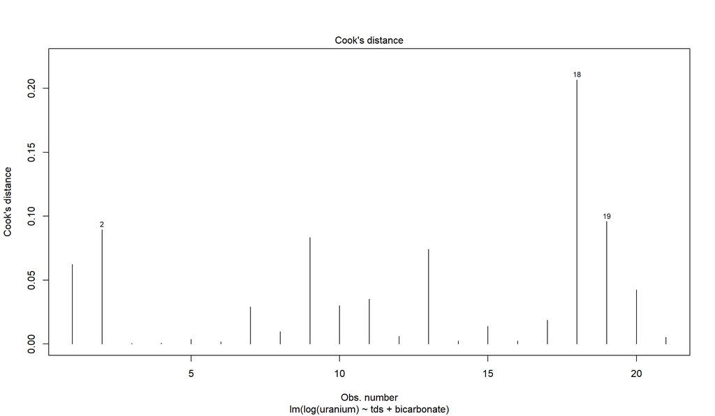

```r
cutoff <- 4/((nrow(app16)-length(fit4$coefficients)-2))
plot(fit4, which=4, cook.levels=cutoff)
```

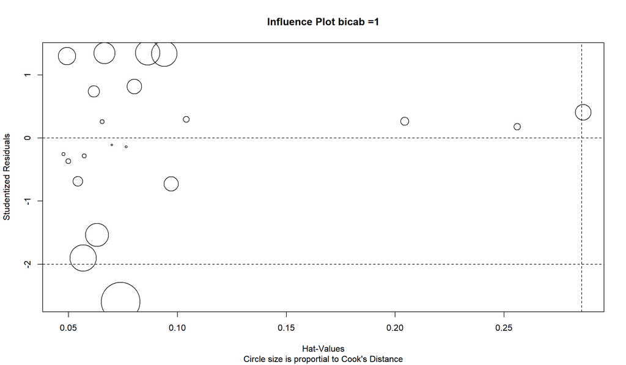

```r
# Influence Plot
influencePlot(fit4, id.method="identify", main="Influence Plot bicab =1", sub="Circle size is proportial to Cook's Distance" )
```

There are not many of the points which particularly influence the regression equation. This model is a great fit, but since the sample size we used to model it is small, there might be problems of overfitting the data with the model that we generated.